# Analysis of Google Trends for Deforestation

Jack Acomb and Ting Huang

3/4/2022

## Introduction

Climate change and environmental degradation stand as some of the most important problems currently facing our nation and our world. However, they also remain some of the most complex problems. Troubling environmental trends emerge in a wide array of contexts, ranging from rates of natural disasters, pollution, global temperatures, water access, and food yields, just to highlight a few. In the midst of such a barrage, remaining focused on each constituent part of the crisis seems challenging, especially for members of the general public.

To that end, today we investigate the American public’s interest in deforestation. According to the most recent United Nations Global Forest Resources Assessment (published in 2020), deforestation has slowed in the past several decades, but remains a significant challenge; they project that “it is unlikely that the Global Forest Goal of increasing the world’s forest area by 3 percent will be met by 2030” (FAO 2020). In that context, it would seem that there is still need for sustained pressure and attention paid to the problem of deforestation. However, in the American context, deforestation is often muted in discourse surrounding climate initiatives and largely absent from the broader political discourse. For example, President Biden’s climate plan does make reference to preventing deforestation, but it is overshadowed by other initiatives like investment in clean energy (“Plan for Climate Change and Environmental Justice: Joe Biden” 2020). In addition, neither of the platforms of the major Minnesota political parties make more than passing reference to forest policy“2020 Platform Committee Report Final” (2020). Given this, we believe that it is worth investigating trends over time in the American public’s interest in deforestation, in hopes of determining to what degree it remains an area of interest in the broader fight against the climate crisis.

## Data

The data utilized in this project comes from Google Trends, which keeps track of the relative interest in certain topics through Google search terms. This is done by taking a random sample of anonymous search data over a specific time period. The data is normalized by comparing the searches for your specified search term with the total searches in the specified time and region. This prevents factors like population from affecting the outcome.

There are only 2 variables in the dataset which are Month, which includes a month and a year, and DFSearches, originally named deforestation, which provides a numerical measure of relative interest in the search term ‘deforestation’ out of 100. Trends scales the search data by setting the peak popularity at 100 for the specified time and region with every other point being in comparison to that. Month gives the month and year when the specified region had that level of relative interest. A plot of the data as provided by Google Trends is available below.

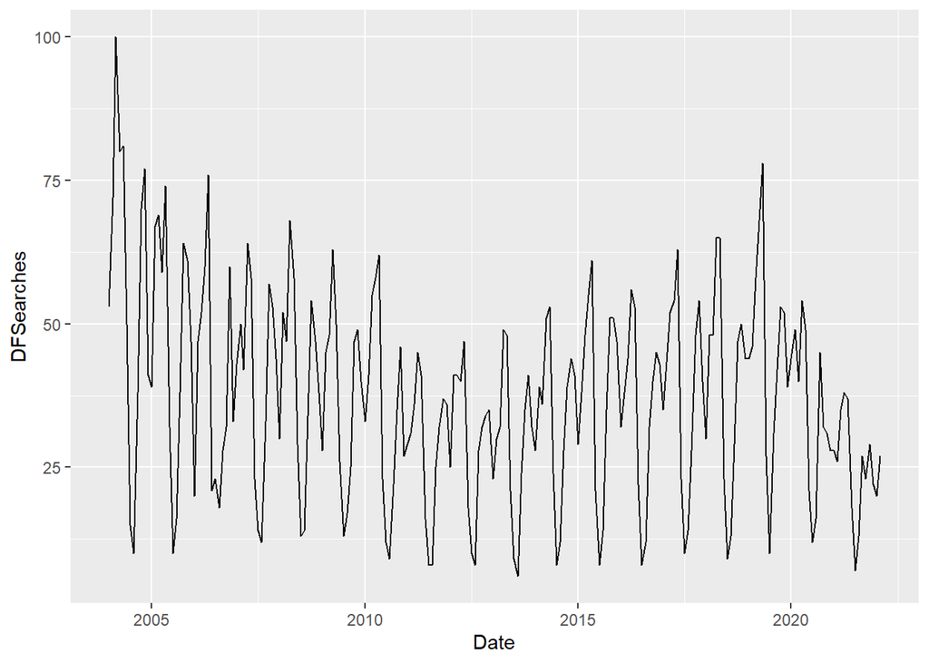

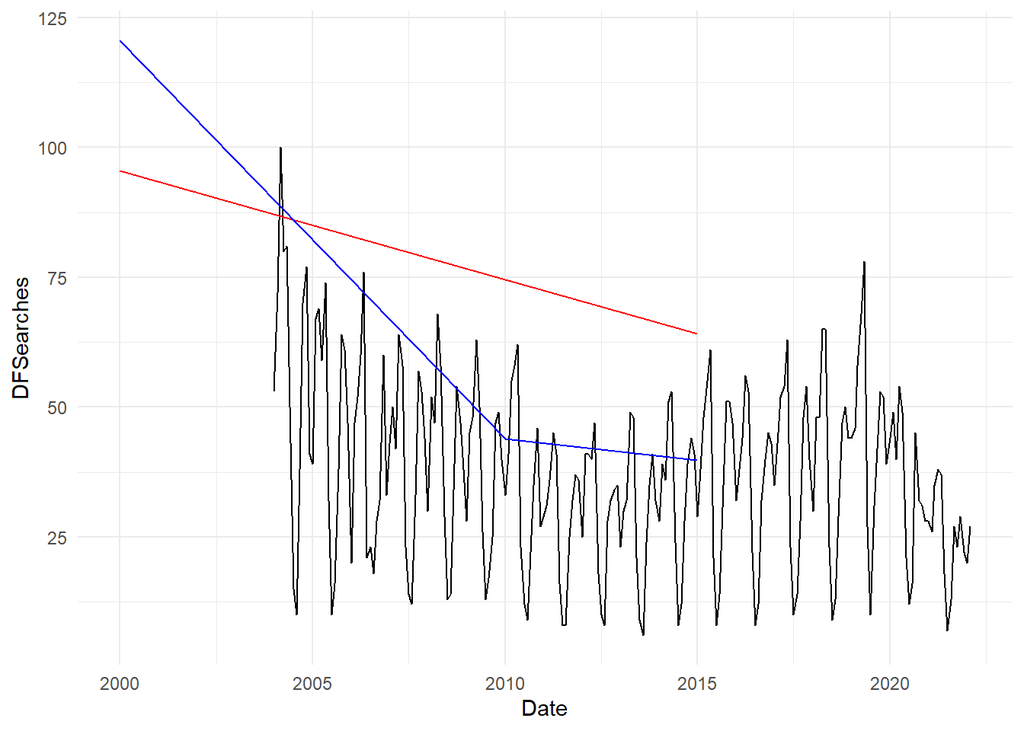

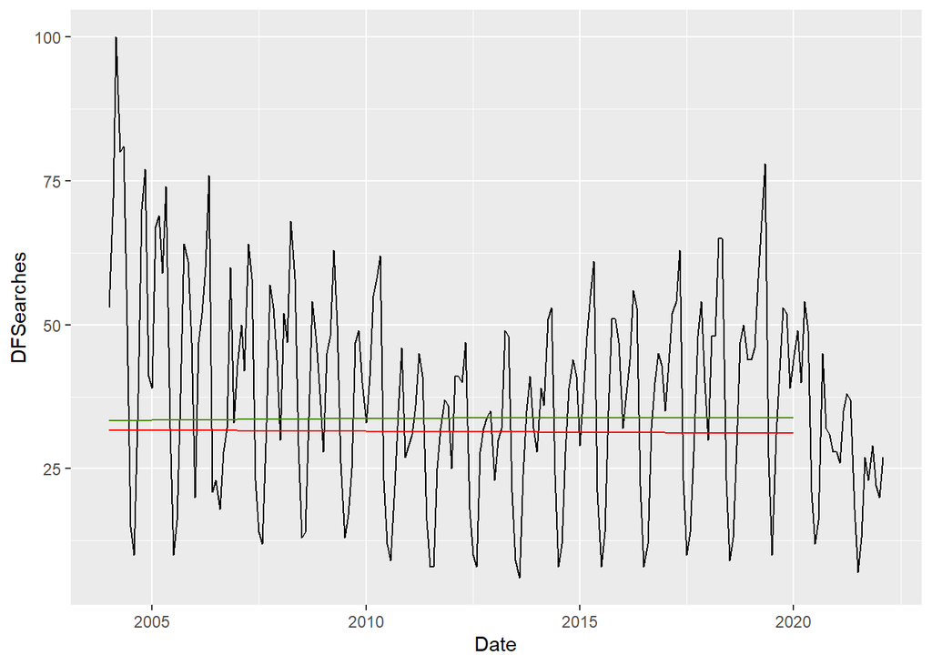

Additionally, for the purposes of contextualization, we provide search trend data alongside trend lines for deforestation metrics in Brazil (in blue) and the world (in red) since 2000 (Ritchie and Roser 2021). As the FAO noted in their 2020 report, deforestation has been on the decline in the past decades, and this decrease is seemingly in line with the decrease in popularity of the search term ‘deforestation’ in the US. However, a similar plot comparing search trends to overall proportions of forest cover (globally in red, in North America in green) seems to show a less meaningful or explanatory trend. While interrogating this correlation is beyond the scope of this project, the authors thought it important to highlight for readers— understanding the relationship between physical conditions and public interest remains an avenue for future inquiry. In either case, there is clearly still significant variation in search trends that remains unexplained, and this variation will be the subject of the bulk of our following analysis.

## Methods

In order to better understand the trend in our data, we attempt to decompose the time series and generate an explanatory model. This section will explain the general methodological approach, with discussion of results in the following section.

As a first step, in order to bring the data closer to constant variance for the purposes of modeling, we transformed the data using a logarithm transformation. We then fit several estimations of trend using different methods (Heggeseth 2022); we ultimately settled on using a basis spline model with knots at the years 2010 and 2019. This provided the dual advantages of being parametric while also avoiding over-fitting.

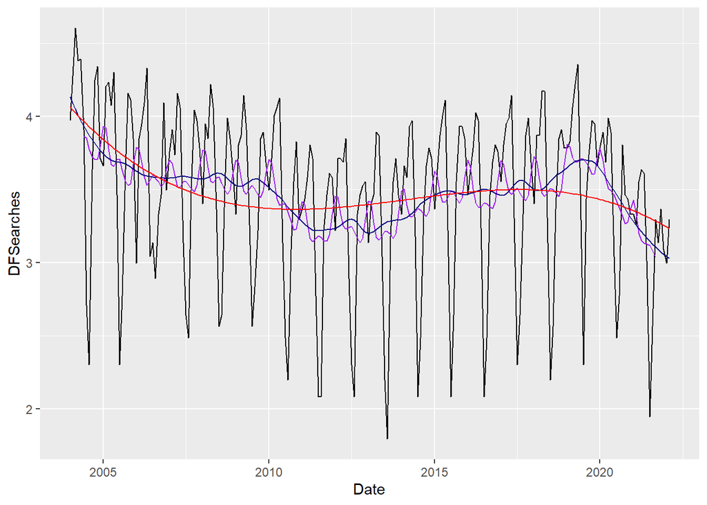

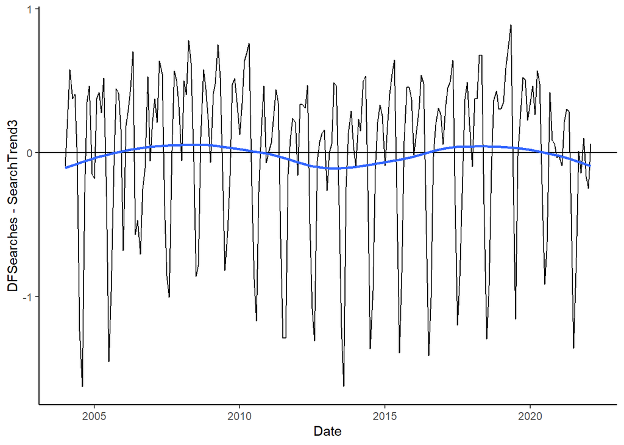

To remove the apparent seasonality in the remaining residuals, we generated a regression model with monthly indicator variables. We selected this method over the use of a defined sine or cosine curve to account for the multiple peaks and troughs that appear over the course of a season.

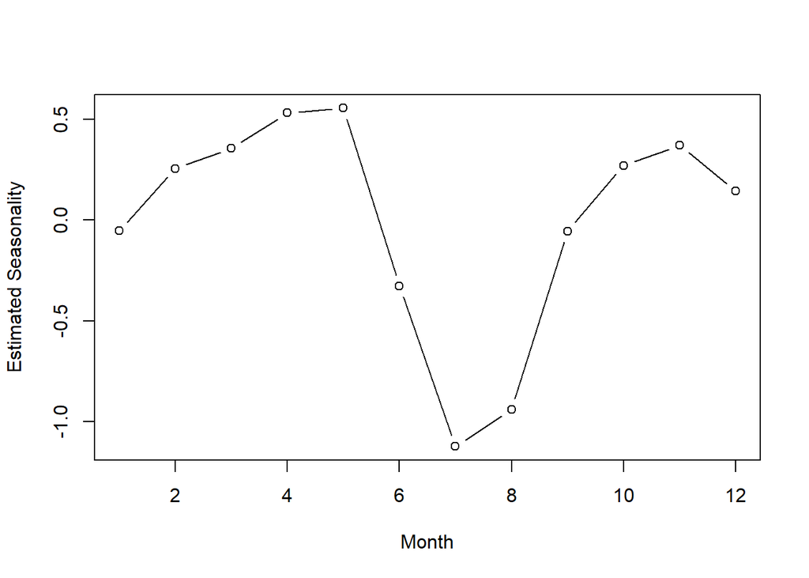

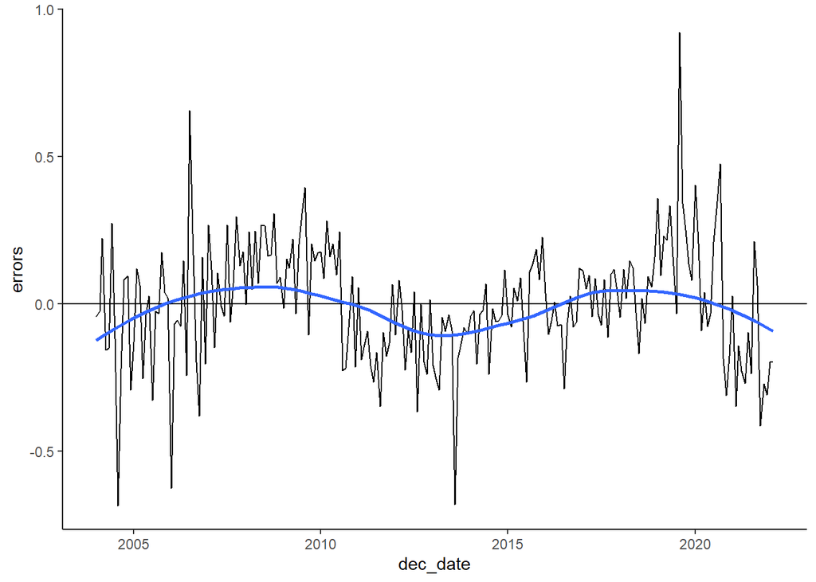

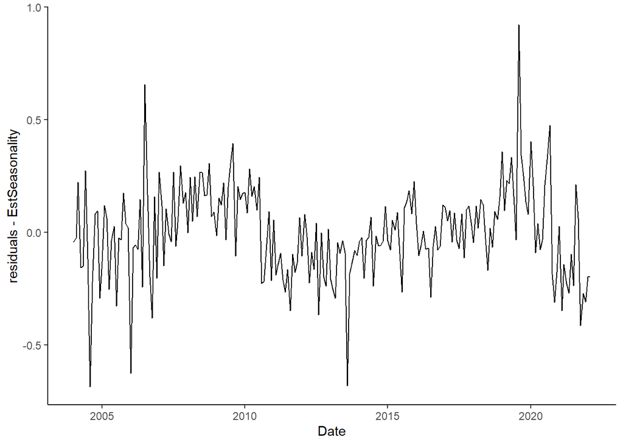

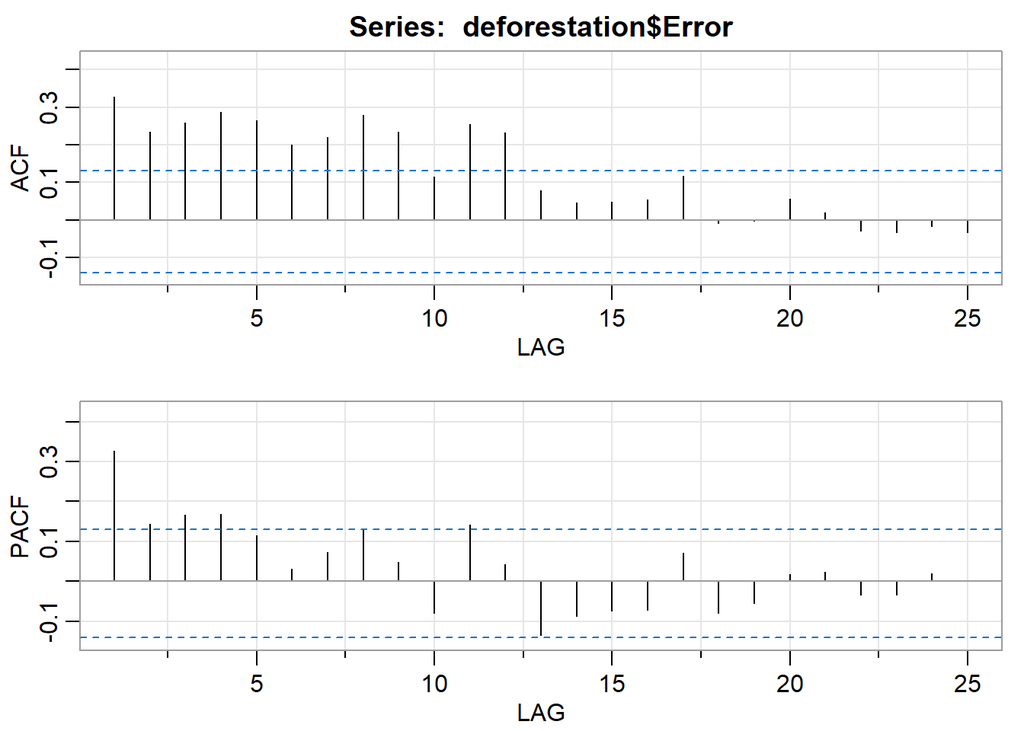

```
##      [,1] [,2] [,3] [,4] [,5] [,6] [,7] [,8] [,9] [,10] [,11] [,12] [,13] [,14]
## ACF  0.33 0.23 0.26 0.29 0.27 0.20 0.22 0.28 0.23  0.11  0.25  0.23  0.08  0.05
## PACF 0.33 0.14 0.17 0.17 0.12 0.03 0.07 0.13 0.05 -0.08  0.14  0.04 -0.14 -0.09
##      [,15] [,16] [,17] [,18] [,19] [,20] [,21] [,22] [,23] [,24] [,25]
## ACF   0.05  0.05  0.12 -0.01  0.00  0.06  0.02 -0.03 -0.03 -0.02 -0.03
## PACF -0.07 -0.07  0.07 -0.08 -0.05  0.02  0.02 -0.03 -0.03  0.02  0.00
```

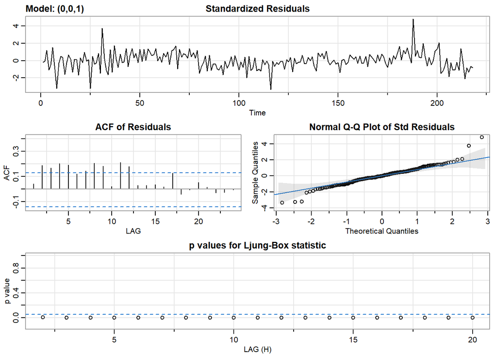

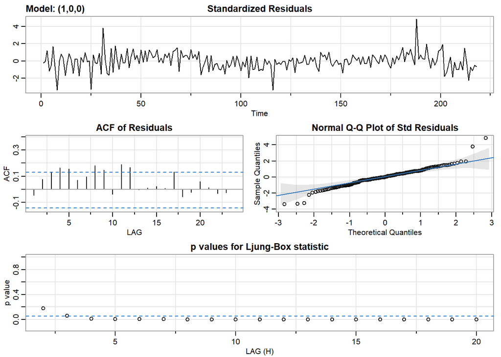

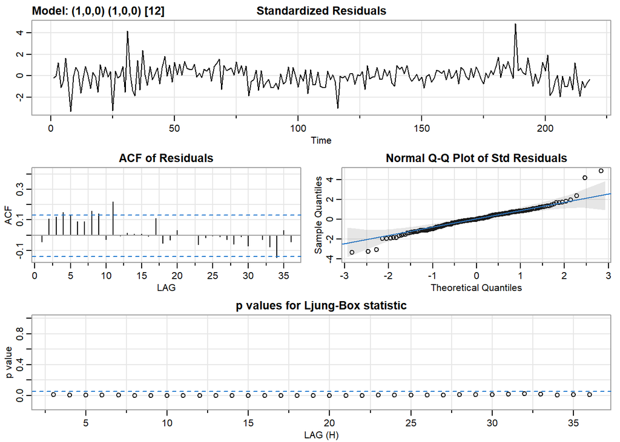

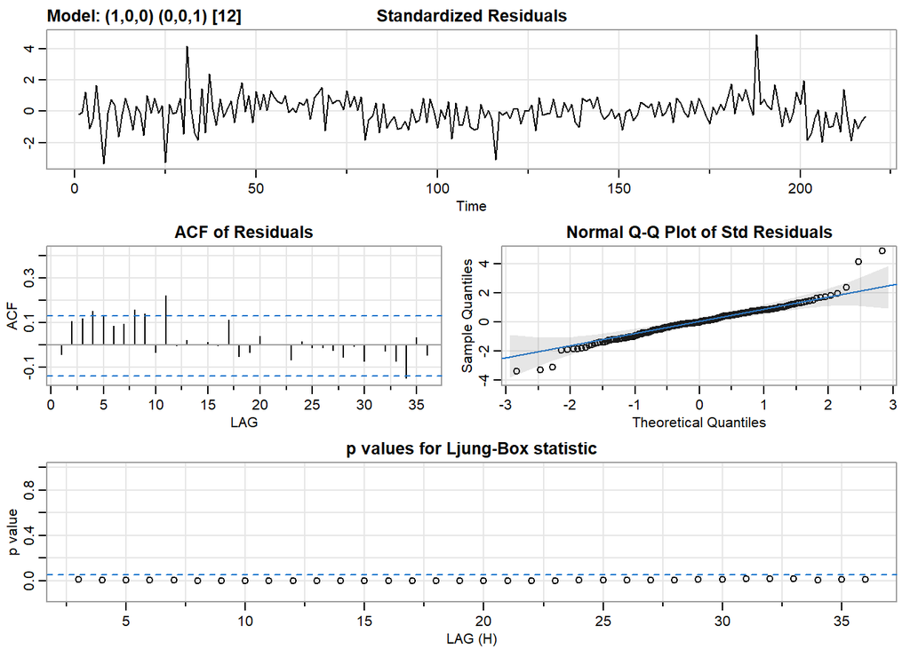

```
## [1] -0.3532858
```

```
## [1] -0.379341
```

```
## [1] -0.3880769
```

```
## [1] -0.3882722
```

For the purposes of analysis and forecasting, the final model will be a re-composition of the three component models (trend, seasonality, and error) as delineated above.

## Results

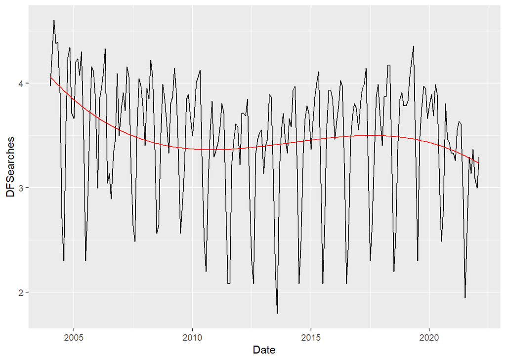

Seasonality analysis on the de-trended data showed that there were typically two yearly peaks in public Google interest in deforestation, roughly centered around April/May and October/November. Conversely, seasonal low-points were, on average, centered around July/August and to a lesser extent December/January.

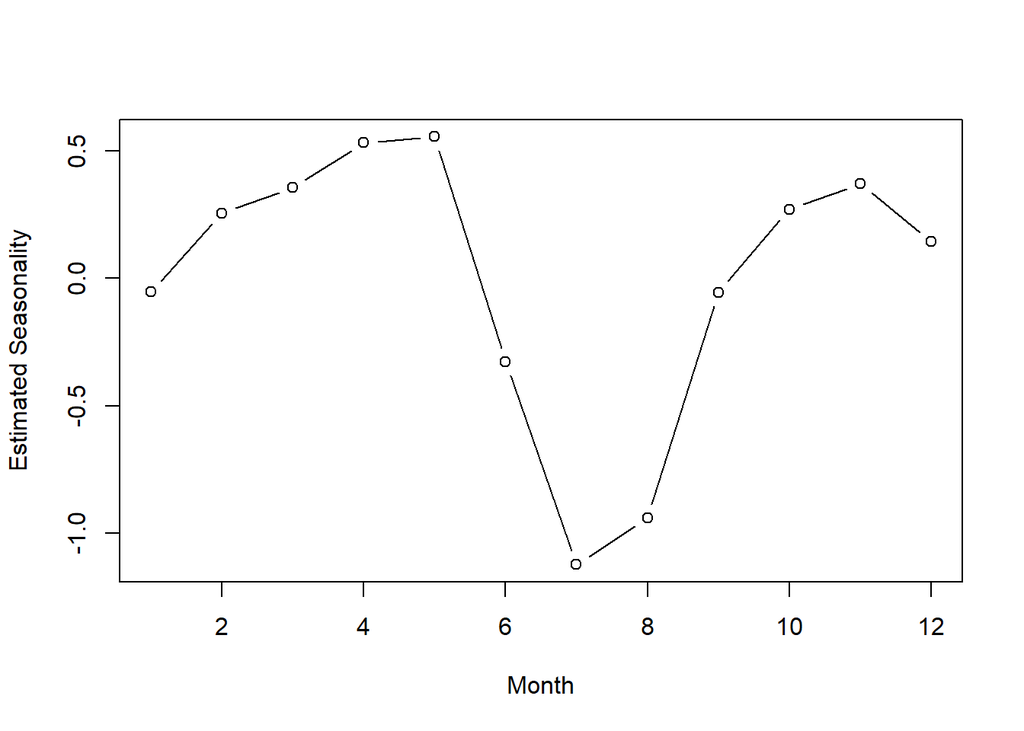

When the models for trend, seasonality, and error were combined, the resulting model performed relatively well; the ACF of residuals remained largely within acceptable bounds, and the p-values for the Ljung-Box statistic were high for large lags, which is desirable.

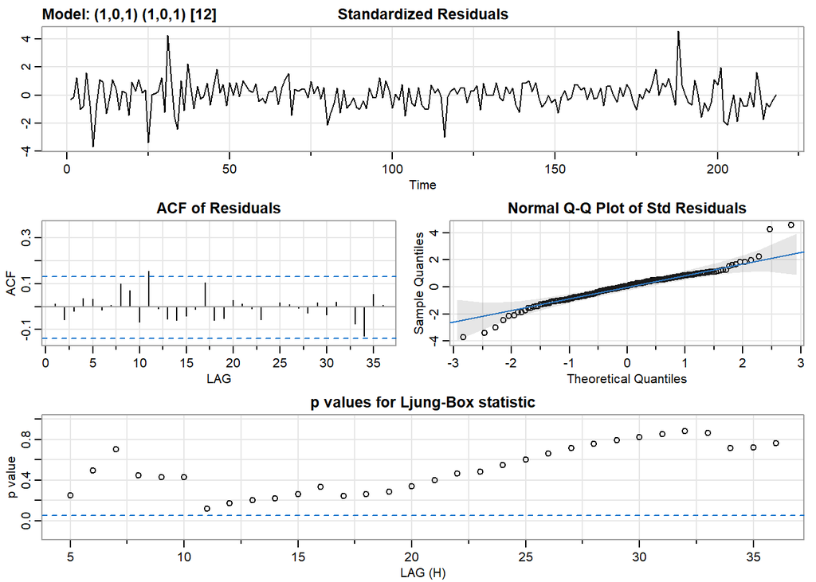

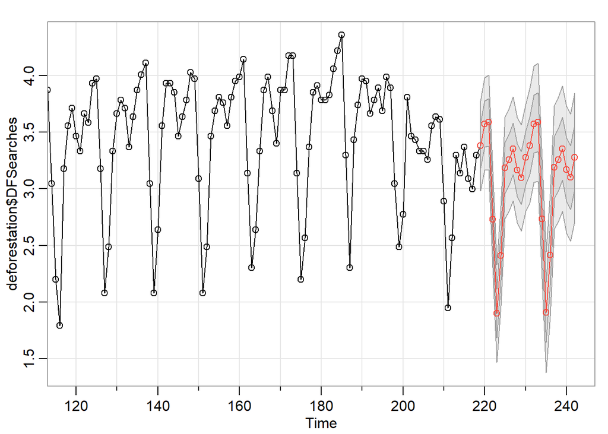

```
## $pred
## Time Series:
## Start = 219
## End = 242
## Frequency = 1
##  [1] 3.379618 3.570222 3.586172 2.729893 1.899506 2.409003 3.185502 3.255149
##  [9] 3.352490 3.165830 3.096045 3.275013 3.381922 3.571370 3.587144 2.735575
## [17] 1.909755 2.416320 3.188396 3.257578 3.354302 3.168616 3.099154 3.277054
##
## $se
## Time Series:
## Start = 219
## End = 242
## Frequency = 1
##  [1] 0.1986737 0.2036087 0.2081508 0.2123410 0.2162143 0.2198007 0.2231267
##  [8] 0.2262154 0.2290870 0.2317598 0.2342498 0.2365717 0.2527974 0.2565869
## [15] 0.2601064 0.2633791 0.2664254 0.2692638 0.2719106 0.2743808 0.2766878
## [22] 0.2788437 0.2808595 0.2827454
```

## Discussion and Conclusions

Our analysis indicates that there is, in fact, a downward trend in proportional interest in the term deforestation over the time period from 2004 until present. This has not been a linear trend, and is interrupted significantly by seasonal highs and lows. Future research may turn more direct attention to what caused the increase in interest in deforestation that peaked in 2019, or what is driving the unsymmetrical seasonal patterns.

The authors do note that the seasonal peaks appear to be line with western academic calenders, while valleys correspond with traditionally western Summer and Winter academic breaks. We thus hypothesize that some of the seasonality may be driven by students researching deforestation during the academic year, and spending less time researching it while on break. However, further analysis would need to be conducted in order to understand if this hypothesis bears out. One approach could be to investigate trends of a similar term in countries that have different academic break schedules than the United States, or to use some sort of metric in the modelling process to control for the academic calender.

Looking toward the forecast for the coming year, it is clear that levels are not expected to rebound based upon our analysis. While our model does not project that search volumes will plummet, it does forecast that interest will remain below historical levels of the past few years, which remains potentially troubling for advocates and activists wishing to move the needle on deforestation efforts. However, this analysis may inform timing of future outreach strategies; given observed seasonal interest patterns, efforts in the Fall and Spring may potentially reach greater audiences than those in the Summer or Winter, increasing efficacy regardless of the underlying macro-trend.

Google Trend data provides a useful window into public interest in given terms, but it is important to note is limitations. As mentioned above, the provided metric of search interest is a proportional measure, where overall search volume over time is controlled for. While this is useful in comparting proportional trends, it may disguise the fact that a greater absolute number of people are searching for a given term, even if they are a proportionally smaller piece of the whole. This phenomenon has been documented in Google Trends data for other ecology related terms (Burivalova, Butler, and Wilcove 2018), and may very-well be the case in this instance as well. Additionally, this data only captures users in the United States, and is inherently limited to those who have access to a computer, the internet, and choose to use Google. These requirements limit access to certain groups of people, and elevate the influence of other groups. A more accurate picture of the public’s interest in deforestation would require a more truly representative sample.

## Acknowledgements

We would like to thank Dr. Brianna Heggeseth for her invaluable guidance on this project.

## References

“2020 Platform Committee Report Final.” 2020. *MNGOP*. https://mngop.com/action-center/2020-platform-committee-report-final/.

Burivalova, Zuzana, Rhett A Butler, and David S Wilcove. 2018. “Analyzing Google Search Data to Debunk Myths about the Public’s Interest in Conservation.” *Frontiers in Ecology and the Environment* 16 (9): 509–14. https://doi.org/10.1002/fee.1962.

FAO. 2020. “Global Forest Resources Assessment 2020.” *FAO.org*. United Nations. https://www.fao.org/3/CA8753EN/CA8753EN.pdf.

Heggeseth, Brianna. 2022. “Correlated Data Notes.” *4.1 Modeling the Trend*. Macalester College. https://bcheggeseth.github.io/CorrelatedData/modeling-the-trend.html.

“Minnesota Democratic-Farmer-Labor Party Ongoing Platform.” n.d. *DFL.org*. https://dfl.org/wp-content/uploads/2020/06/DFL-Ongoing-Platform-1.pdf.

“Plan for Climate Change and Environmental Justice: Joe Biden.” 2020. *Joe Biden for President: Official Campaign Website*. https://joebiden.com/climate-plan/.

Ritchie, Hannah, and Max Roser. 2021. “Deforestation and Forest Loss.” *Our World in Data*. University of Oxford, Combinator. https://ourworldindata.org/deforestation.